# Intro to Bayesian software

## Outline

- Model output
  - structure, convergence, summarizing, inference & visuals
- Other software
  - Rstan, Nimble

## Model structure (Likelihood)

\[y_i \sim Normal(\mu_i, \sigma)\]  
- \(y_i\): mpg for each make & model  
- \(\mu_i\): expected mpg  
- \(\sigma\): standard deviation

## Model structure (Likelihood)

\[\mu_i = \alpha_0 + \alpha_1 \times x_{1,i} + \alpha_2 \times x_{2,i}\]

- \(\alpha_0\): intercept (mean mpg of 4 cyl)
- \(\alpha_1\): effect of 6 cyl (difference in mpg between 4 and 6 cyl)
- \(\alpha_2\): effect of 8 cyl (difference in mpg between 4 and 8 cyl)
- \(x_{1,i}\): dummy vector for 6 cyl (1 for 6 cyl, 0 otherwise)
- \(x_{2,i}\): dummy vector for 8 cyl (1 for 8 cyl, 0 otherwise)

## Output summary

```r
summary(out)
```

```
## Summary for model 'Model.txt'
## Saved parameters: alpha0 alpha1 alpha2 tau sigma mean2 mean3 deviance
## MCMC ran for 0.013 minutes at time 2020-07-28 09:46:57.
##
## For each of 3 chains:
## Adaptation:            100 iterations (sufficient)
## Burn-in:               100 iterations
## Thin rate:             1 iterations
## Total chain length:    1200 iterations
## Posterior sample size: 1000 draws
##
## Successful convergence based on Rhat values (all < 1.1).
##
## DIC info: (pD = var(deviance)/2)
## pD = 4.7 and DIC = 171.554
```

## Output

```r
out
```

```
## JAGS output for model 'Model.txt', generated by jagsUI.
## Estimates based on 3 chains of 1100 iterations,
## adaptation = 100 iterations (sufficient),
## burn-in = 100 iterations and thin rate = 1,
## yielding 3000 total samples from the joint posterior.
## MCMC ran for 0.013 minutes at time 2020-07-28 09:46:57.
##
##             mean    sd    2.5%     50%   97.5% overlap0 f  Rhat n.eff
## alpha0    26.620 1.002  24.647  26.635  28.600    FALSE 1 1.000  3000
## alpha1    -6.875 1.613 -10.019  -6.816  -3.715    FALSE 1 1.000  3000
## alpha2   -11.505 1.345 -14.162 -11.500  -8.914    FALSE 1 1.000  3000
## tau        0.096 0.025   0.052   0.094   0.151    FALSE 1 1.000  3000
## sigma      3.316 0.456   2.573   3.262   4.367    FALSE 1 1.000  3000
## mean2     19.745 1.257  17.322  19.745  22.215    FALSE 1 1.000  3000
## mean3     15.115 0.904  13.286  15.131  16.900    FALSE 1 1.000  3000
## deviance 166.842 3.069 163.061 166.115 174.676    FALSE 1 1.001  3000
##
## Successful convergence based on Rhat values (all < 1.1).
## Rhat is the potential scale reduction factor (at convergence, Rhat=1).
## For each parameter, n.eff is a crude measure of effective sample size.
##
## overlap0 checks if 0 falls in the parameter's 95% credible interval.
## f is the proportion of the posterior with the same sign as the mean;
## i.e., our confidence that the parameter is positive or negative.
##
## DIC info: (pD = var(deviance)/2)
## pD = 4.7 and DIC = 171.554
## DIC is an estimate of expected predictive error (lower is better).
```

## Output object

```r
ls(out)
```

```
##  [1] "bugs.format" "calc.DIC"    "DIC"         "f"           "mcmc.info"
##  [6] "mean"        "model"       "modfile"     "n.eff"       "overlap0"
## [11] "parallel"    "parameters"  "pD"          "q2.5"        "q25"
## [16] "q50"         "q75"         "q97.5"       "Rhat"        "run.date"
## [21] "samples"     "sd"          "sims.list"   "summary"
```

## Convergence

- MCMC searches parameter space
- Must verify that we are within the stable distribution
  - Check our burn-in: is it long enough?
  - Multiple chains: are they mixing well?
  - Diagnostics
    - Visual: traceplot: looks at mixing

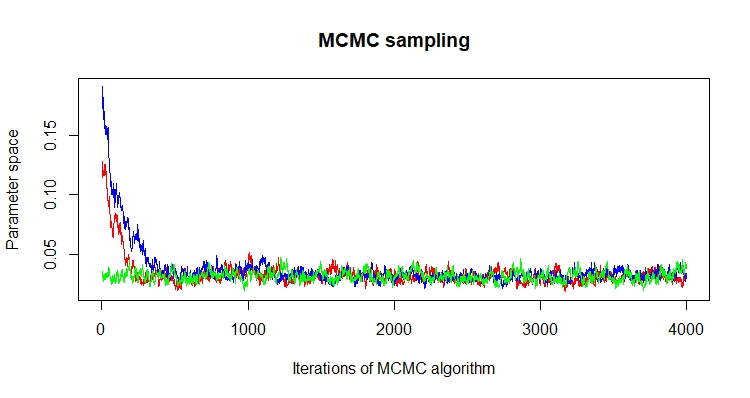

## More diagnostics

- Numeric: Gelman-Rubin (Rhat):
  - derived test statistic (between vs within chain variance)
  - values < 1.1 are considered converged
- Effective sample size (independent draws of posterior)
  - the higher the better

## Traceplot

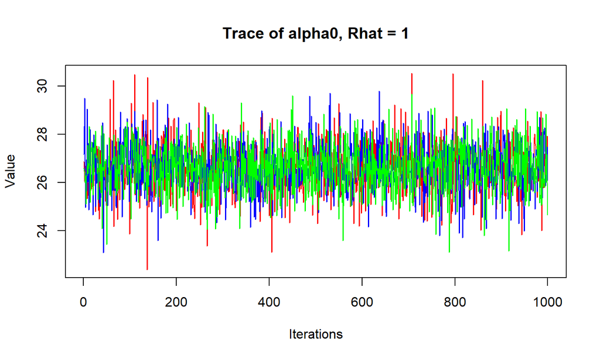

```r
traceplot(out, "alpha0")
```

## Traceplot

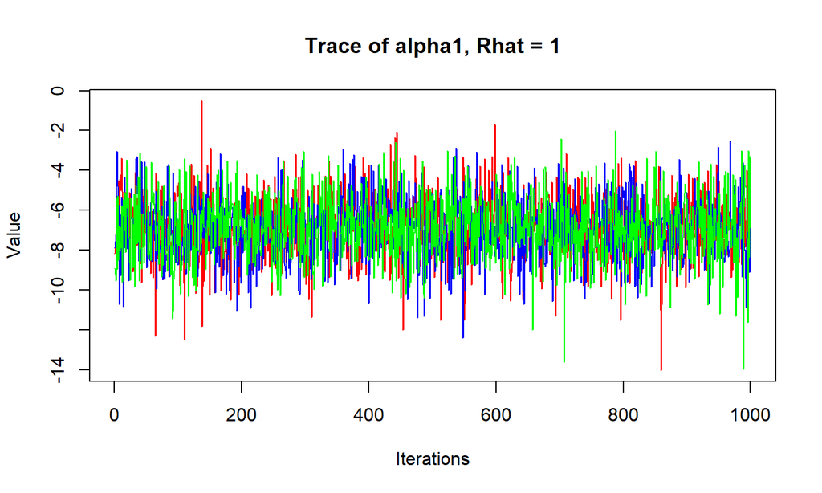

```r
traceplot(out, "alpha1")
```

## Traceplot

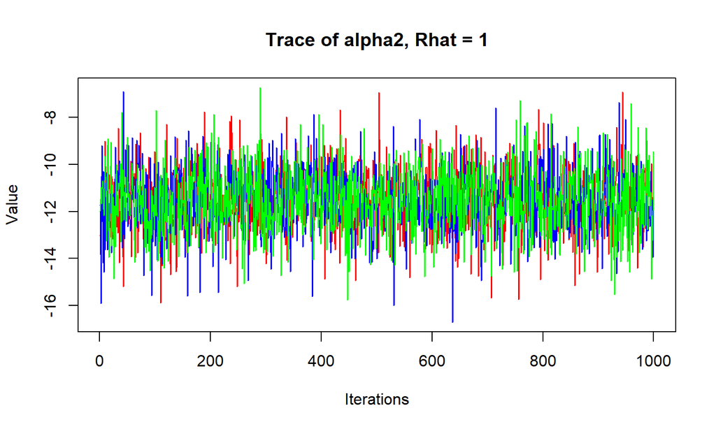

```r
traceplot(out, "alpha2")
```

## Traceplot

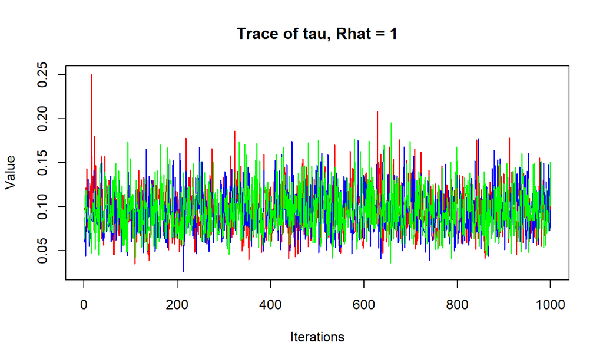

```r
traceplot(out, "tau")
```

## Rhat

```r
t(out$Rhat); all(out$Rhat < 1.1)
```

```
##      alpha0   alpha1   alpha2    tau      sigma     mean2     mean3
## [1,] 1.000356 1.000338 0.9996387 1.000125 0.9998978 0.9999448 0.9999891
##      deviance
## [1,] 1.001182
```

```
## [1] TRUE
```

## Effective sample size

```r
t(out$n.eff)
```

```
##      alpha0 alpha1 alpha2 tau  sigma mean2 mean3 deviance
## [1,] 3000   3000   3000   3000 3000  3000  3000  3000
```

## Improve convergence

- Model structure
- Alternative priors
- Initial values
- MCMC settings
- Alternative MCMC algorithms (eg, Stan, Nimble)

## Model fit

- Posterior predictive check
- Bayesian p-value

```
for(i in 1:nobs){
  res[i] <- y[i] - mu[i]
  y.new[i] ~ dnorm(mu[i], tau)
  res.new[i] <- y.new[i] - mu[i]
}

fit <- sum(res[])
fit.new <- sum(res.new[])
```

## PP-check

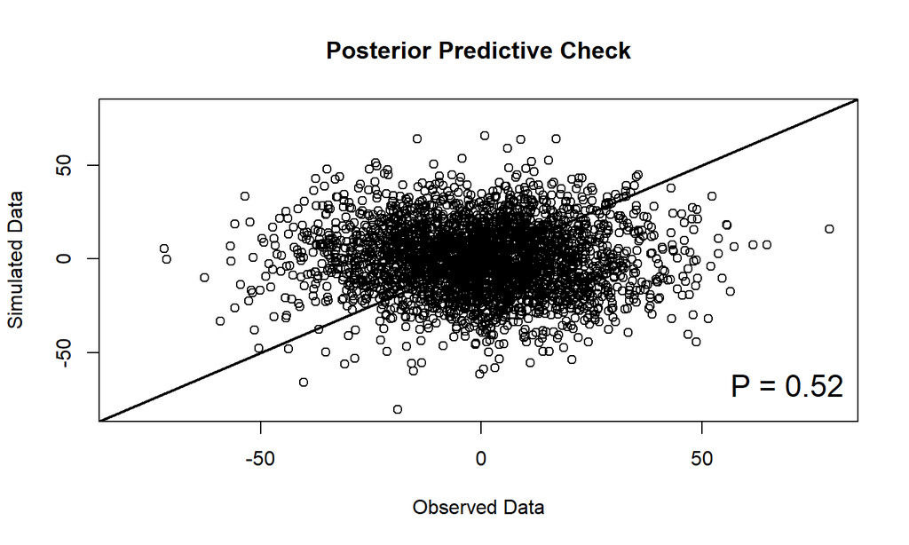

```
## [1] 0.5166667
```

```r
jagsUI::pp.check(out.check, 'fit', 'fit.new')
```

## Posterior estimations

```r
posterior <- data.frame(matrix(unlist(out$sims.list), ncol=length(out$sims.list), byrow=F))
colnames(posterior) <- names(out$sims.list)
dim(posterior)
```

```
## [1] 3000    8
```

## Posterior plots

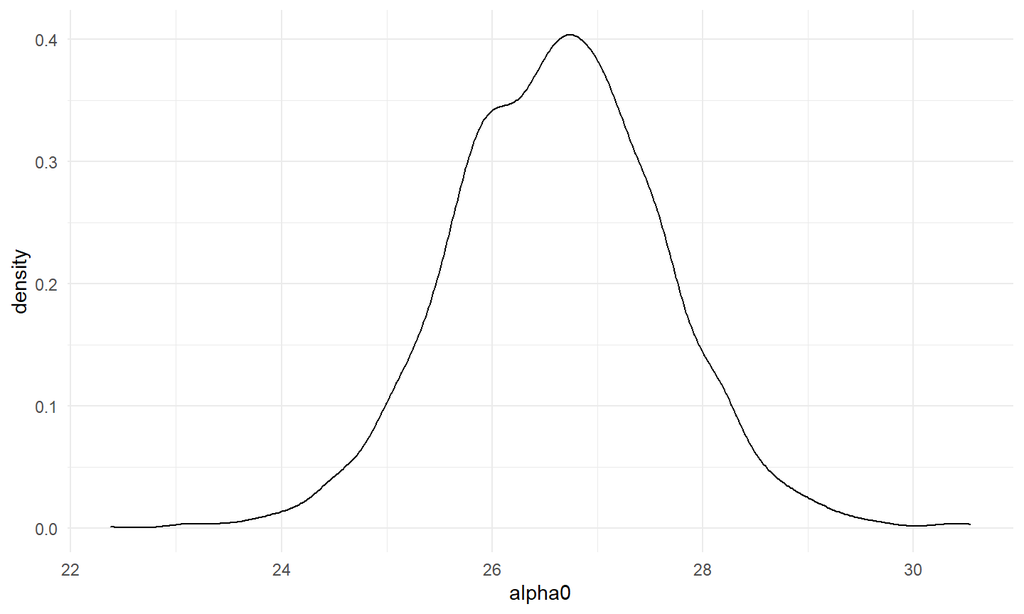

```r
ggplot(posterior) +
  geom_density(aes(x=alpha0),) + theme_minimal()
```

## Summarize posterior

- Calculate mean and sd
- Credible intervals

```r
out$mean$alpha0; out$sd$alpha0; out$q2.5$alpha0; out$q97.5$alpha0
```

```
## [1] 26.62026
```

```
## [1] 1.002249
```

```
## [1] 24.64654
```

```
## [1] 28.60001
```

## Since we’re Bayesian

- Probability statements can be made directly about the posterior

Ex/ probability that a 4 cyl vehicle has a fuel economy greater than 28 mpgs?

```r
sum(out$sims.list$alpha0 > 28)/out$mcmc.info$n.samples * 100
```

```
## [1] 8.233333
```

## What about test statistics

- Check to see if 95% CI overlaps zero.
  - Better yet… report the actual probability.

Ex/ probability that 4 cyl have a higher mean mpg than 6 cyl?

```r
out$overlap0$alpha1; out$f$alpha1; sum(out$sims.list$alpha1 < 0)/out$mcmc.info$n.samples
```

```
## [1] FALSE
```

```
## [1] 1
```

```
## [1] 1
```

## Visually see this…

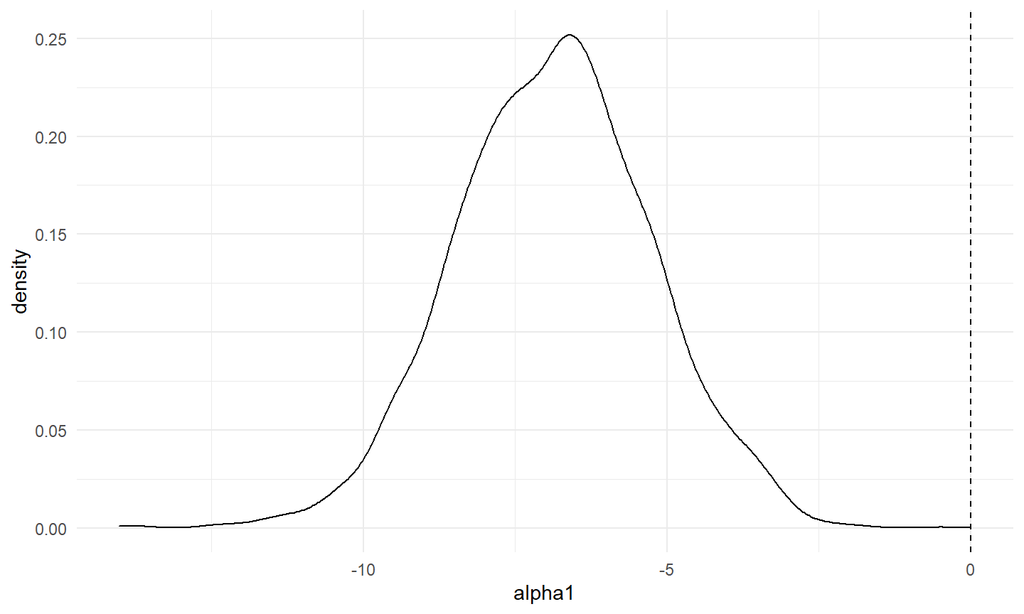

```r
ggplot(posterior) + geom_density(aes(x=alpha1)) +
  geom_vline(aes(xintercept=0), linetype = "dashed") + theme_minimal()
```

## Another example

Differences between 2 non-baseline groups

```r
sum(out$sims.list$mean2 > out$sims.list$mean3)/out$mcmc.info$n.samples
```

```
## [1] 0.998
```

There is a 99.8% chance that a v6 engine has a greater fuel economy than a v8.

## Nimble

```r
library(nimble)
MSdyn.c <- nimbleCode({

  ##Likelihood
  for(i in 1:nobs){
    y[i] ~ dnorm(mu[i], tau) #likelihood function
    mu[i] <- alpha0 + alpha1 * x1[i] + alpha2 * x2[i] #linear model of the mean
    res[i] <- y[i] - mu[i] #residuals
    y.new[i] ~ dnorm(mu[i], tau) #simulated data
    res.new[i] <- y.new[i] - mu[i] #simulated residuals
  }
  ##Priors
  alpha0 ~ dnorm(0, 0.001) #mean of 4 cyl
  alpha1 ~ dnorm(0, 0.001) #effect of 6 cyl
  alpha2 ~ dnorm(0, 0.001) #effect of 8 cyl
  tau ~ dgamma(0.001, 0.001) #precision
  ##Derived values
  sigma <- 1/sqrt(tau) #relationship between SD and precision
  mean2 <- alpha0 + alpha1 #mean of 6 cyl
  mean3 <- alpha0 + alpha2 #mean of 8 cyl
  fit <- sum(res[1:nobs])
  fit.new <- sum(res.new[1:nobs])
  })
```

## Nimble

```r
data <- list(y = mtcars$mpg,
             x1 = ifelse(mtcars$cyl==6,1,0),
             x2 = ifelse(mtcars$cyl==8,1,0),
             nobs = dim(mtcars)[1])

inits <- function(){list(
  alpha0 = runif(1, 10, 33),
  alpha1 = runif(1, -1, 1),
  alpha2 = runif(1, -1, 1),
  tau = runif(1, 0, 1)
)}

params <- c("alpha0", "alpha1", "alpha2", "tau", "sigma", "mean2", "mean3")

nc <- 3
ni <- 1100
nb <- 100
nt <- 1
```

## Nimble

```r
MSdyn.m <- nimbleModel(MSdyn.c, constants = data, inits = inits())
```

```
## Detected y as data within 'constants'.
```

```r
MCMCconf <- configureMCMC(MSdyn.m, monitors = params)
```

```
## ===== Monitors =====
## thin = 1: alpha0, alpha1, alpha2, tau, sigma, mean2, mean3
## ===== Samplers =====
## posterior_predictive sampler (32)
##   - y.new[]  (32 elements)
## conjugate sampler (4)
##   - alpha0
##   - alpha1
##   - alpha2
##   - tau
```

```r
MCMC <- buildMCMC(MCMCconf)

MSdyn.comp <- compileNimble(MSdyn.m, MCMC)
```

## Nimble

```r
MSdyn.o <- runMCMC(MSdyn.comp$MCMC, niter = ni, nburnin = nb, nchains = nc, thin = nt,
                   setSeed = c(1,2,3), samplesAsCodaMCMC = TRUE)
```

## Nimble

```r
summary(MSdyn.o)
```

```
##
## Iterations = 1:1000
## Thinning interval = 1
## Number of chains = 3
## Sample size per chain = 1000
##
## 1. Empirical mean and standard deviation for each variable,
##    plus standard error of the mean:
##
##             Mean      SD  Naive SE Time-series SE
## alpha0  26.59512 1.02202 0.0186595      0.0617675
## alpha1  -6.82764 1.64443 0.0300230      0.0824115
## alpha2 -11.47322 1.37158 0.0250416      0.0803476
## mean2   19.76748 1.27210 0.0232252      0.0419576
## mean3   15.12191 0.91095 0.0166315      0.0301537
## sigma    3.30116 0.44505 0.0081254      0.0139324
## tau      0.09664 0.02527 0.0004613      0.0008056
##
## 2. Quantiles for each variable:
##
##             2.5%       25%       50%     75%   97.5%
## alpha0  24.55809  25.90292  26.59602  27.284 28.6132
## alpha1 -10.04651  -7.94336  -6.79257  -5.745 -3.5801
## alpha2 -14.14520 -12.34596 -11.51310 -10.588 -8.6307
## mean2   17.23683  18.90058  19.78544  20.604 22.3600
## mean3   13.39863  14.52922  15.09855  15.707 16.9870
## sigma    2.56750   2.98829   3.25885   3.558  4.3122
## tau      0.05378   0.07897   0.09416   0.112  0.1517
```

## Stan

```r
cat("
  data{

  }

  parameters{

  }

  transformed parameters{

  }

  model{

  }
  ", fill=TRUE, file="Model.stan")
```

## Stan

```r
cat("
  data{
    int<lower=0> nobs; //number of observations
    int<lower=0> K; //number of parameters
    vector[nobs] y; //observed mpg
    matrix[nobs, K] x; //design matrix
  }

  parameters{
    vector[K] alpha; //parameters
    real<lower=0> sigma; // standard deviation
  }

  model{

  }
  ", fill=TRUE, file="Model.stan")
```

## Stan

```r
cat("
  data{
    int<lower=0> nobs; //number of observations
    int<lower=0> K; //number of parameters
    vector[nobs] y; //observed mpg
    matrix[nobs, K] x; //design matrix
  }

  parameters{
    vector[K] alpha; //parameters
    real<lower=0> sigma; // standard deviation
  }

  model{

    //Priors
    target += normal_lpdf(sigma|0,100);
    target += normal_lpdf(alpha|0,100);

    //Likelihood
    y ~ normal(alpha * x, sigma); //likelihood
    // target += normal_lpdf(y|alpha*x, sigma);
  }
  ", fill=TRUE, file="Model.stan")
```

## Stan

```
  generated quantities{
    vector[K] meancyl;
    meancyl[1] = alpha[1];
    meancyl[2] = alpha[1] + alpha[2];
    meancyl[3] = alpha[1] + alpha[3];
  }
```

## Compile data

```r
data <- list(y = mtcars$mpg,
             x = model.matrix(mpg~as.factor(cyl), data = mtcars),
             nobs = dim(mtcars)[1],
             K = 3)
```

## MCMC settings

```r
nc <- 3 #number of chains
ni <- 1100 #number of iterations
nb <- 100 #length of burn-in
nt <- 1 #number to thin by
```

## Initial values

```r
alpha.fun <- function(){
  alpha <- NULL
  alpha[1] <- runif(1, 10, 33)
  alpha[2] <- runif(1, -1, 1)
  alpha[3] <- runif(1, -1, 1)
  return(alpha)
}

inits <- function(){list(alpha = alpha.fun(), sigma = runif(1, 0, 10))}
```

## Parameters to save

```r
params <- c("alpha", "sigma", "meancyl")
```

## Run model

```r
out.stan <- stan(file = "Model.stan", data = data, init = inits, pars = params,
                 chains = nc, iter = ni, warmup = nb, thin = nt,
                 open_progress = FALSE)
```

## Output

```r
out.stan
```

```
## Inference for Stan model: Model.
## 3 chains, each with iter=1100; warmup=100; thin=1;
## post-warmup draws per chain=1000, total post-warmup draws=3000.
##
##              mean se_mean   sd   2.5%    25%    50%    75%  97.5% n_eff Rhat
## alpha[1]    26.66    0.04 1.04  24.61  25.97  26.66  27.35  28.72   766    1
## alpha[2]    -6.88    0.06 1.61 -10.06  -7.97  -6.85  -5.82  -3.78   805    1
## alpha[3]   -11.59    0.05 1.37 -14.17 -12.52 -11.56 -10.69  -8.86   851    1
## sigma        3.37    0.01 0.47   2.59   3.04   3.32   3.66   4.44  2315    1
## meancyl[1]  26.66    0.04 1.04  24.61  25.97  26.66  27.35  28.72   766    1
## meancyl[2]  19.79    0.03 1.27  17.33  18.95  19.77  20.62  22.28  1346    1
## meancyl[3]  15.08    0.02 0.91  13.37  14.49  15.07  15.69  16.88  2148    1
## lp__       -52.89    0.05 1.51 -56.74 -53.60 -52.55 -51.79 -51.03   889    1
##
## Samples were drawn using NUTS(diag_e) at Tue Jul 28 09:49:10 2020.
## For each parameter, n_eff is a crude measure of effective sample size,
## and Rhat is the potential scale reduction factor on split chains (at
## convergence, Rhat=1).
```

## Rstanarm

```r
library(rstanarm)
out.stanarm <- stan_glm(mpg ~ as.factor(cyl), data = mtcars, family = gaussian(),
                        prior = normal(0, 100), prior_intercept = normal(0, 100), #optional
                        iter = 1100, chains = 3, warmup = 100)
```

## Output

```r
summary(out.stanarm)
```

```
##
## Model Info:
##  function:     stan_glm
##  family:       gaussian [identity]
##  formula:      mpg ~ as.factor(cyl)
##  algorithm:    sampling
##  sample:       3000 (posterior sample size)
##  priors:       see help('prior_summary')
##  observations: 32
##  predictors:   3
##
## Estimates:
##                   mean   sd    10%   50%   90%
## (Intercept)      26.7    1.0  25.4  26.7  27.9
## as.factor(cyl)6  -6.8    1.6  -8.9  -6.8  -4.8
## as.factor(cyl)8 -11.6    1.3 -13.3 -11.6  -9.9
## sigma             3.3    0.4   2.8   3.3   3.9
##
## Fit Diagnostics:
##            mean   sd   10%   50%   90%
## mean_PPD 20.1    0.8 19.1  20.1  21.2
##
## The mean_ppd is the sample average posterior predictive distribution of the outcome variable (for details see help('summary.stanreg')).
##
## MCMC diagnostics
##                 mcse Rhat n_eff
## (Intercept)     0.0  1.0  1129
## as.factor(cyl)6 0.0  1.0  2739
## as.factor(cyl)8 0.0  1.0  2982
## sigma           0.0  1.0  1069
## mean_PPD        0.0  1.0   904
## log-posterior   0.0  1.0   818
##
## For each parameter, mcse is Monte Carlo standard error, n_eff is a crude measure of effective sample size, and Rhat is the potential scale reduction factor on split chains (at convergence Rhat=1).
```

## Brms

```r
library(brms)
out.brms <- brm(mpg ~ as.factor(cyl), data = mtcars, family = gaussian(),
                prior = c(set_prior("normal(0,100)", class = "b")), #optional
                iter = 1100, chains = 3, warmup = 100)
```

## Output

```r
summary(out.brms)
```

```
##  Family: gaussian
##   Links: mu = identity; sigma = identity
## Formula: mpg ~ as.factor(cyl)
##    Data: mtcars (Number of observations: 32)
## Samples: 3 chains, each with iter = 1100; warmup = 100; thin = 1;
##          total post-warmup samples = 3000
##
## Population-Level Effects:
##               Estimate Est.Error l-95% CI u-95% CI Rhat Bulk_ESS Tail_ESS
## Intercept        26.60      1.00    24.60    28.60 1.00     1164     1263
## as.factorcyl6    -6.87      1.60    -9.99    -3.71 1.01      951     1031
## as.factorcyl8   -11.50      1.31   -14.11    -8.81 1.01      895     1062
##
## Family Specific Parameters:
##       Estimate Est.Error l-95% CI u-95% CI Rhat Bulk_ESS Tail_ESS
## sigma     3.36      0.48     2.58     4.42 1.00     2611     1724
##
## Samples were drawn using sampling(NUTS). For each parameter, Bulk_ESS
## and Tail_ESS are effective sample size measures, and Rhat is the potential
## scale reduction factor on split chains (at convergence, Rhat = 1).
```

## Resources

MSU courses - FW 849 Applied Bayesian Inference using Monte Carlo Methods for Quantitative Biologists (Fall of even years)  
- IBIO 860 Modern Statistical Models in Ecology (On demand)  
- STT 465 Bayesian Statistical Methods (Fall of every year)  
- STT 874 Introduction to Bayesian Analysis (Fall of even years)  
- STT 997 Advanced Topics in Statistics (Keep your eyes open)

Books - Kéry, M. (2010) Introduction to WinBUGS for ecologists: aBayesian approach to regression, ANOVA, mixed models, and related analyses. Academic Press.  
- Gelman et al. [Bayesian Data Analysis](http://www.stat.columbia.edu/~gelman/book/BDA3.pdf)

Workshops - KBS summer graduate workshops  
- [Nimble workshops](https://r-nimble.org/)  
- [Stan workshops](https://mc-stan.org/workshops/)

## Resources

- JAGS
  - https://sourceforge.net/projects/mcmc-jags/files/Manuals/4.x/jags_user_manual.pdf/download
  - https://sourceforge.net/p/mcmc-jags/discussion/
- Nimble
  - https://r-nimble.org/html_manual/cha-welcome-nimble.html
  - https://groups.google.com/forum/#!forum/nimble-users
- Stan
- https://mc-stan.org/docs/2_23/stan-users-guide/index.html
- https://discourse.mc-stan.org/